# Video Game Analysis

Samuel Enokela

5/3/2022

Data Visualization - Video Games sales Exploratory Analysis Using R By Samuel Enokela 03/05/2022 1)Introduction The aim of this analysis is to develop insights from the video game sales data using R programming language. The data is in ‘.csv’ format and covers a time span between 1980 to 2020.

2. Loading Libraries The below libraries were used tidyverse ggplot2 hrbrthemes viridis The last two libraries were used for theme and colour gradient in the plots.

```r
library(tidyverse)
```

```r
library(ggplot2)
library(viridis)
library(hrbrthemes)
```

Importing and Cleaning Data

```r
vg_data <- read.csv('C:/Users/samen/Desktop/Data Analysis/R/Video Game Analysis/vgsales.csv')
head(vg_data)
```

```
##   Rank                     Name Platform Year        Genre Publisher NA_Sales
## 1    1               Wii Sports      Wii 2006       Sports  Nintendo    41.49
## 2    2        Super Mario Bros.      NES 1985     Platform  Nintendo    29.08
## 3    3           Mario Kart Wii      Wii 2008       Racing  Nintendo    15.85
## 4    4        Wii Sports Resort      Wii 2009       Sports  Nintendo    15.75
## 5    5 Pokemon Red/Pokemon Blue       GB 1996 Role-Playing  Nintendo    11.27
## 6    6                   Tetris       GB 1989       Puzzle  Nintendo    23.20
##   EU_Sales JP_Sales Other_Sales Global_Sales
## 1    29.02     3.77        8.46        82.74
## 2     3.58     6.81        0.77        40.24
## 3    12.88     3.79        3.31        35.82
## 4    11.01     3.28        2.96        33.00
## 5     8.89    10.22        1.00        31.37
## 6     2.26     4.22        0.58        30.26
```

```r
str(vg_data)
```

```
## 'data.frame':    16598 obs. of  11 variables:
##  $ Rank        : int  1 2 3 4 5 6 7 8 9 10 ...
##  $ Name        : chr  "Wii Sports" "Super Mario Bros." "Mario Kart Wii" "Wii Sports Resort" ...
##  $ Platform    : chr  "Wii" "NES" "Wii" "Wii" ...
##  $ Year        : chr  "2006" "1985" "2008" "2009" ...
##  $ Genre       : chr  "Sports" "Platform" "Racing" "Sports" ...
##  $ Publisher   : chr  "Nintendo" "Nintendo" "Nintendo" "Nintendo" ...
##  $ NA_Sales    : num  41.5 29.1 15.8 15.8 11.3 ...
##  $ EU_Sales    : num  29.02 3.58 12.88 11.01 8.89 ...
##  $ JP_Sales    : num  3.77 6.81 3.79 3.28 10.22 ...
##  $ Other_Sales : num  8.46 0.77 3.31 2.96 1 0.58 2.9 2.85 2.26 0.47 ...
##  $ Global_Sales: num  82.7 40.2 35.8 33 31.4 ...
```

Though the file has data between 1980 - 2020, there are only three observations for 2017, one for 2020 and none for the years 2018 and 2019. Therefore we will move on with our analysis for the duration between 1980 - 2016.

Also there are NA values in Year and Publisher column but its representation is in the form of N/A. We will replace these N/A values with NA so that it can be read as NA. Also we will count the NAs in the df.

```r
vg_data[vg_data == "N/A"] <- NA
vg_data %>% summarise(across(everything(), ~sum(is.na(.))))
```

```
##   Rank Name Platform Year Genre Publisher NA_Sales EU_Sales JP_Sales
## 1    0    0        0  271     0        58        0        0        0
##   Other_Sales Global_Sales
## 1           0            0
```

```r
vg_data_cleaned <- subset(vg_data, Year != 2017 & Year != 2020) %>%
  drop_na(Year)

vg_data_cleaned$Year <- as.numeric(vg_data_cleaned$Year)
head(vg_data_cleaned)
```

```
##   Rank                     Name Platform Year        Genre Publisher NA_Sales
## 1    1               Wii Sports      Wii 2006       Sports  Nintendo    41.49
## 2    2        Super Mario Bros.      NES 1985     Platform  Nintendo    29.08
## 3    3           Mario Kart Wii      Wii 2008       Racing  Nintendo    15.85
## 4    4        Wii Sports Resort      Wii 2009       Sports  Nintendo    15.75
## 5    5 Pokemon Red/Pokemon Blue       GB 1996 Role-Playing  Nintendo    11.27
## 6    6                   Tetris       GB 1989       Puzzle  Nintendo    23.20
##   EU_Sales JP_Sales Other_Sales Global_Sales
## 1    29.02     3.77        8.46        82.74
## 2     3.58     6.81        0.77        40.24
## 3    12.88     3.79        3.31        35.82
## 4    11.01     3.28        2.96        33.00
## 5     8.89    10.22        1.00        31.37
## 6     2.26     4.22        0.58        30.26
```

Data has been cleaned by dropping rows for years 2017,2020 and rows with as NA.

Publisher with NA values were not dropped as it will not affect the analysis

```r
#checking for duplicates
sum(duplicated(vg_data_cleaned))
```

```
## [1] 0
```

No duplicates found

4. Visualization and Insights 4.1 Number of games sold each (Based on Genre)

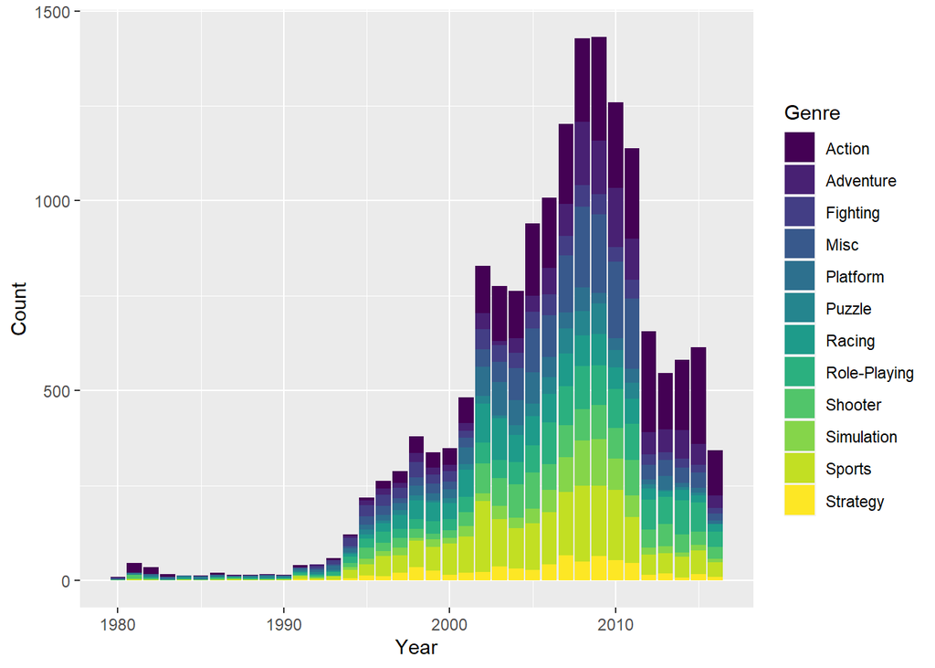

```r
vg_data_cleaned %>% group_by(Year, Genre) %>% summarize(total = n()) %>% ggplot(aes(x = Year, y =total, fill = Genre)) + geom_bar(position = "stack", stat = "identity") + scale_fill_viridis(discrete = T) + labs(tittle = "Total games per year stacked" , y = "Count")
```

```r
theme_bw()
```

[output not shown]

[output cut: 365 more lines]

[output not shown]

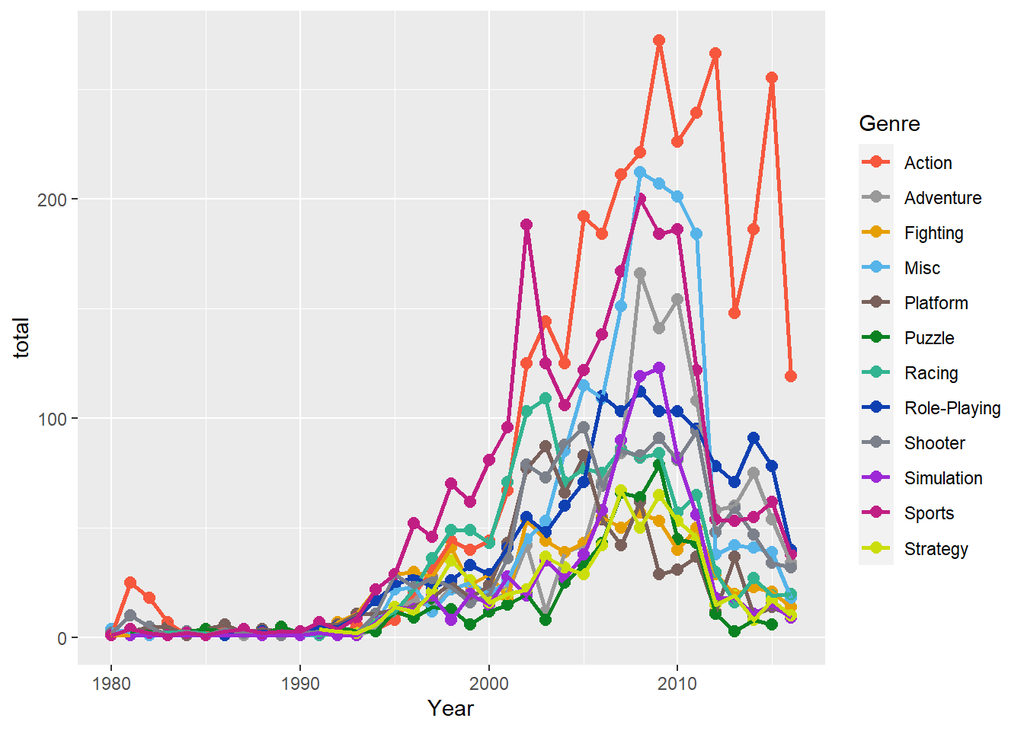

```r
vg_data_cleaned %>% group_by(Year, Genre) %>% summarise(total = n()) %>% ggplot(aes(x = Year, y = total, color = Genre)) +
  geom_point(size = 2.5) +
  geom_line(size = 1) +
  scale_color_manual (values = c("#F6573D", "#999999", "#E69F00", "#56B4E9", "#79605B", "#0A8222", "#32B491","#0F40B2", "#7B808A", "#9D29D6","#C11E83", "#CBDE0B"))
```

```r
labs(title = "Game count by Genre per Year") + theme_bw()
```

summarize() has grouped output per “Year”. You can override sing the ‘.groups’ argument

The stacked bar plot shows that the overall sales of video game increased drastically over the period 1990 to 2008 and then started to decline after that. For the last 10 years the sale was dominated by ‘Action’ genre which can also be seen from line plot of total games sold based on genre.

4.2 Sales Plot Global Sales Plot

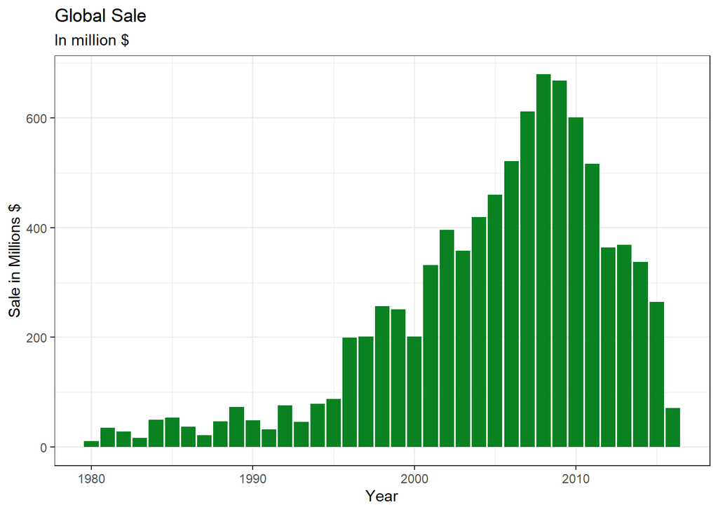

```r
vg_data_cleaned %>% group_by(Year) %>% summarise(total_global_sale = sum(Global_Sales)) %>% ggplot(aes(x = Year, y = total_global_sale, fill = I("#0A8222"))) + geom_col() + labs(title = "Global Sale", subtitle = "In million $", y = "Sale in Millions $") + theme_bw()
```

Global sales value has the same trend as the number of games sold

Sales Percentage Variation of Different region

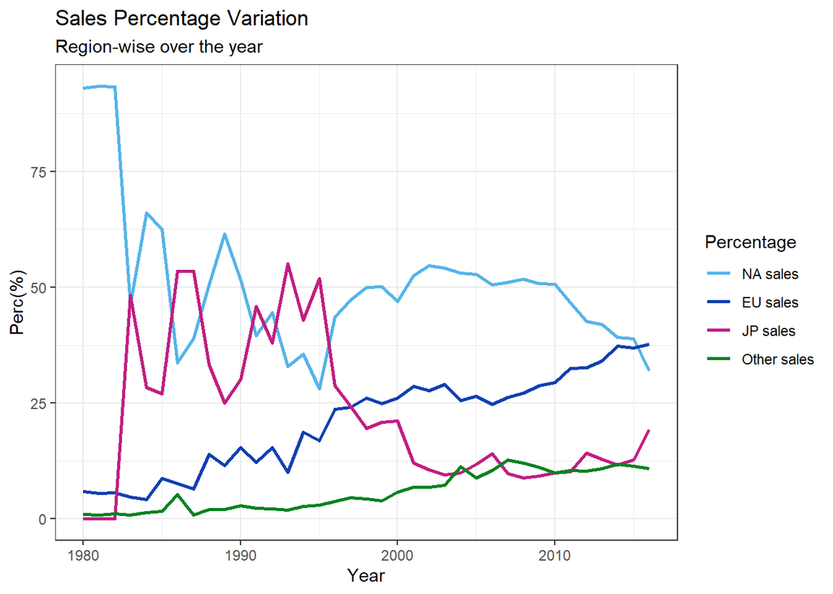

```r
vg_data_cleaned %>%
  group_by(Year) %>%
  summarise(total_NA_sales = sum(NA_Sales),
            total_EU_sales = sum(EU_Sales),
            total_JP_sales = sum(JP_Sales),
            total_other_sales = sum(Other_Sales),
            total_global_sales = sum(Global_Sales)) %>%
  mutate(perc_NA_sales = total_NA_sales/total_global_sales * 100,
         perc_EU_sales = total_EU_sales/total_global_sales * 100,
         perc_JP_sales = total_JP_sales/total_global_sales * 100,
         perc_other_sales = total_other_sales/total_global_sales * 100) %>%
  ggplot() +
  geom_line(aes(x = Year, y = perc_NA_sales, colour = "NA sales"), size = 1) +
  geom_line(aes(x= Year, y= perc_EU_sales, colour = "EU sales"), size = 1) +
  geom_line(aes(x= Year, y= perc_JP_sales, colour = "JP sales"), size = 1) +
  geom_line(aes(x= Year, y= perc_other_sales, colour = "Other sales"), size = 1) +
  scale_color_manual(values = c ("NA sales" = "#56B4E9", "EU sales" = "#0F40B2", "JP sales" = "#C11E83", "Other sales" = "#0A8222")) +
  labs(title = "Sales Percentage Variation", subtitle = "Region-wise over the year ", y = "Perc(%)", colour = "Percentage") +
  theme_bw()
```

4.3 Evolution of Gaming Platform

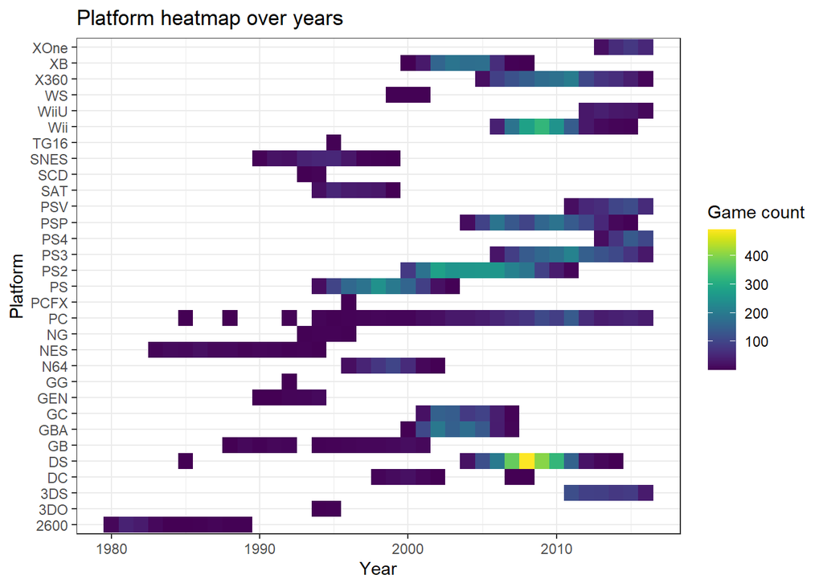

```r
vg_data_cleaned %>%
  group_by(Year, Platform) %>%
  summarise(game_count = n()) %>%
  ggplot(aes(x =Year, y = Platform, fill = game_count)) + geom_tile() + scale_fill_viridis(discrete = FALSE) + labs (title = "Platform heatmap over years", fill = "Game count")+
  theme_bw()
```

summarise () has grouped output by Year. You can override using the ‘.groups’ argument.

The plot shows how the gaming platform evolved over the year. PC gaming is having the heighest run whereas other platforms either became obsolete or was upgraded with time. Currenty only few platforms are active on which games are released. There are few observations which indicate some issue with the data. For example, the above heatmap shows that for PS-V the data is available few years before the data of PS-4 which is not correct. Still this plots give a fair idea of how the platform has evolved over the years.

4.5 Top Game and Publisher

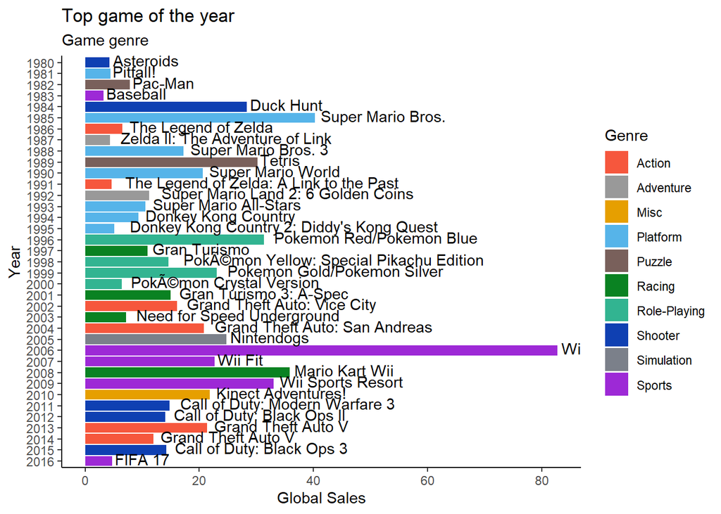

```r
vg_data_cleaned %>%
  group_by(Year) %>%
  arrange(desc(Global_Sales)) %>%
  slice(1) %>%
  ggplot(aes(y = reorder(Year, -Year), x = Global_Sales, fill= Genre)) +
  geom_col() +
   scale_fill_manual(values=c("#F6573D", "#999999", "#E69F00", "#56B4E9", "#79605B",
                             "#0A8222", "#32B491","#0F40B2", "#7B808A", "#9D29D6",
                             "#C11E83", "#CBDE0B"))+
  geom_text(aes(label = Name), position = position_dodge2(width = 1), hjust = -0.05, vjust = 0.3) +
  labs(title = "Top game of the year", subtitle = "Game genre", x = "Global Sales",y ="Year") +
  theme_classic()
```

The above plot shows the top game each year based on the global sales. It also show the genre of the game. It is clear from the plot that top selling game are from various genre.

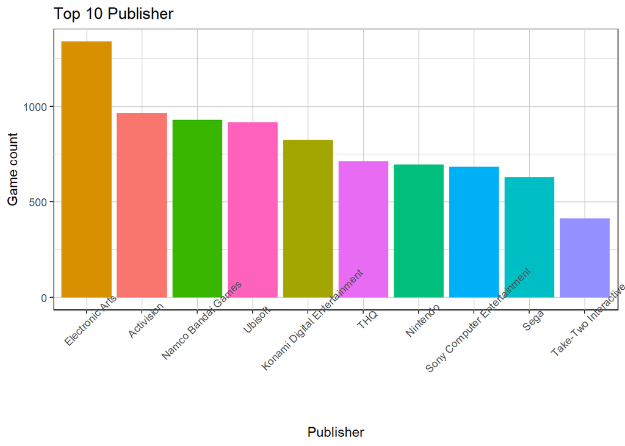

```r
vg_data_cleaned %>%
  group_by(Publisher) %>%
  summarise(title_nos = n()) %>%
  arrange(desc(title_nos)) %>%
  slice(1:10) %>%
  ggplot(aes(x = reorder(Publisher, -title_nos), y = title_nos, fill = Publisher)) +
  geom_col() +
  labs(title = "Top 10 Publisher", x = "Publisher", y = "Game count") +
  theme(axis.text.x = element_text(angle = 45), legend.position = "none",
        panel.background = element_rect(fill = "white",colour = "black",size = 0.5, linetype = "solid"),
        panel.grid.major = element_line(size = 0.25, linetype = 'solid',colour = "grey"),
        panel.grid.minor = element_line(size = 0.25, linetype = 'solid',colour = "grey"))
```

The plot shows top 10 Publishers over the entire duration. The top publisher is Electronic Arts followed by Activision.